# EDA

2024-01-26

# 1. EDA

```r
path <- here("data", "Data_SAS.xlsx")
data <- readxl::read_xlsx(path, sheet = 2)
# data %>% glimpse()
# data %>% summary()
```

## 1.1 Data checking

```r
# Copying the original dataframe
data_filtered <- data

# Converting numerical columns to numeric format
numeric_columns <- c("age", "disease duration", "THF dose", "gait", "arm dropping",
                          "shoulder shaking", "elbow rigidity", "wrist rigidity", "head rotation",
                          "glabella tap", "tremor", "salivation", "akathisia", "Total score SAS",
                          "P1", "P2", "P3", "P4", "P5", "P6", "P7", "Positive scale",
                          "N1", "N2", "N3", "N4", "N5", "N6", "N7", "Negative scale",
                          "G1", "G2", "G3", "G4", "G5", "G6", "G7", "G8", "G9", "G10",
                          "G11", "G12", "G13", "G14", "G15", "G16", "General Psychopathology scale",
                          "Total score PANSS", "Verbal Memory", "ZVM", "Digit Sequencing", "ZDS",
                          "Token Motor Task", "ZMT", "Verbal Fluency", "ZVF", "Symbol Coding", "ZSC",
                          "Tower of London", "ZToL", "Comp Z")

# Changing all decimal separators to dots
data_filtered[numeric_columns] <- lapply(data_filtered[numeric_columns], function(x) {
  as.numeric(gsub(",", ".", x))
})

# Converting categorical columns to factors
factor_columns <- c("gender", "visit", "antipsychotic","antipsychotic dose",
                    "course", "education", "smoke", "antipsychotic generation")

data_filtered[factor_columns] <- lapply(data_filtered[factor_columns], as_factor)

#data_filtered %>% glimpse()
```

Checking if PANSS is calculated correctly

```r
# Creating columns
data_compare <- data_filtered %>%
  mutate(
    Positive_scale_auto = rowSums(select(., P1:P7)),
    Negative_scale_auto = rowSums(select(., N1:N7)),
    General_Psychopathology_scale_auto = rowSums(select(., G1:G16)),
    Total_score_PANSS_auto = Positive_scale_auto + Negative_scale_auto + General_Psychopathology_scale_auto
  )

# Comparing
differences_pos_scale <- data_compare %>%
  filter(`Positive scale` != Positive_scale_auto)

differences_neg_scale <- data_compare %>%
  filter(`Negative scale` != Negative_scale_auto)

differences_gen_psychopathology <- data_compare %>%
  filter(`General Psychopathology scale` != General_Psychopathology_scale_auto)

differences_total_panss <- data_compare %>%
  filter(`Total score PANSS` != Total_score_PANSS_auto)

# Displaying results
cat("Differences in Positive scale:\n")
```

```
## Differences in Positive scale:
```

```r
print(differences_pos_scale[, c("id", "Positive scale", "Positive_scale_auto")])
```

```
## # A tibble: 17 × 3
##    id    `Positive scale` Positive_scale_auto
##    <chr>            <dbl>               <dbl>
##  1 А11                  0                  14
##  2 А15                 18                  20
##  3 п14                  0                  15
##  4 п1                   0                  18
##  5 п14                  0                  11
##  6 А28                 23                  20
##  7 А8                   0                  14
##  8 А10                  0                  17
##  9 п13                  0                  14
## 10 п10                  0                  13
## 11 п11                  0                  13
## 12 А7                   0                  16
## 13 п12                  0                  16
## 14 п12                  0                  12
## 15 п9                   0                  12
## 16 А9                   0                  22
## 17 А29                 11                  12
```

```r
cat("\nDifferences in Negative scale:\n")
```

```
##
## Differences in Negative scale:
```

```r
print(differences_neg_scale[, c("id", "Negative scale", "Negative_scale_auto")])
```

```
## # A tibble: 20 × 3
##    id    `Negative scale` Negative_scale_auto
##    <chr>            <dbl>               <dbl>
##  1 А4                   0                  21
##  2 А6                   0                  20
##  3 А11                  0                  19
##  4 п14                  0                  19
##  5 п14                  0                  14
##  6 А8                   0                  22
##  7 А10                  0                  17
##  8 п13                  0                  20
##  9 п13                  0                  15
## 10 п10                  0                  20
## 11 п11                  0                  20
## 12 п10                  0                  15
## 13 п11                  0                  13
## 14 А7                   0                  20
## 15 п12                  0                  18
## 16 п12                  0                  14
## 17 п9                   0                  22
## 18 п9                   0                  15
## 19 А9                   0                  18
## 20 А27                 22                  23
```

```r
cat("\nDifferences in General Psychopathology scale:\n")
```

```
##
## Differences in General Psychopathology scale:
```

```r
print(differences_gen_psychopathology[, c("id", "General Psychopathology scale", "General_Psychopathology_scale_auto")])
```

```
## # A tibble: 22 × 3
##    id    `General Psychopathology scale` General_Psychopathology_scale_auto
##    <chr>                           <dbl>                              <dbl>
##  1 А4                                  0                                 40
##  2 А6                                  0                                 38
##  3 А11                                 0                                 35
##  4 п14                                 0                                 39
##  5 п1                                  0                                 39
##  6 п14                                 0                                 33
##  7 п21                                30                                 28
##  8 А8                                  0                                 42
##  9 А10                                 0                                 35
## 10 п13                                 0                                 42
## # ℹ 12 more rows
```

```r
cat("\nDifferences in Total score PANSS:\n")
```

```
##
## Differences in Total score PANSS:
```

```r
print(differences_total_panss[, c("id", "Total score PANSS", "Total_score_PANSS_auto")])
```

```
## # A tibble: 9 × 3
##   id    `Total score PANSS` Total_score_PANSS_auto
##   <chr>               <dbl>                  <dbl>
## 1 А15                    99                    101
## 2 А20                    50                     49
## 3 п21                    55                     53
## 4 А28                    91                     88
## 5 п33                    71                     61
## 6 п13                    63                     66
## 7 А9                     44                     59
## 8 А29                    60                     62
## 9 А27                    64                     65
```

## 1.2 Error Correction

A script, preprocessing.R, has been created to replace incorrect data: - Corrects identified errors in the scales. - Adds a 5-factor model. - Adds chlorpromazine equivalents. - Creates Data_SAS_fixed.xlsx in _misc.

```r
path <- here("scripts/0_preprocessing", "preprocessing.R")
source(path)
path <- here("data", "Data_SAS.xlsx")
data_filtered <- preprocessing(path)
```

## 1.3 EDA - fixed data

```r
data_filtered %>%
  select("gender", "age", "disease duration", "antipsychotic dose", "antipsychotic generation", "THF dose", "course", "education", "smoke", "Total score SAS", "Total score PANSS", "Comp Z", "CPZE") %>%
  describe() %>%
  select(vars, n, mean, sd, median, min, max, range) %>%
  round(3) %>%
  kable("html") %>%
  kable_styling("striped", full_width = FALSE)
```

|  | vars | n | mean | sd | median | min | max | range |
| --- | --- | --- | --- | --- | --- | --- | --- | --- |
| gender* | 1 | 108 | 1.519 | 0.502 | 2.00 | 1.00 | 2.00 | 1.00 |
| age | 2 | 108 | 30.667 | 8.582 | 31.00 | 18.00 | 51.00 | 33.00 |
| disease duration | 3 | 108 | 9.037 | 6.519 | 8.00 | 1.00 | 32.00 | 31.00 |
| antipsychotic dose* | 4 | 108 | 9.185 | 3.963 | 10.00 | 1.00 | 18.00 | 17.00 |
| antipsychotic generation* | 5 | 108 | 2.167 | 0.791 | 2.00 | 1.00 | 3.00 | 2.00 |
| THF dose | 6 | 108 | 3.444 | 2.635 | 4.00 | 0.00 | 12.00 | 12.00 |
| course* | 7 | 108 | 2.167 | 1.204 | 2.00 | 1.00 | 4.00 | 3.00 |
| education* | 8 | 108 | 2.519 | 1.308 | 2.50 | 1.00 | 4.00 | 3.00 |
| smoke* | 9 | 108 | 1.315 | 0.467 | 1.00 | 1.00 | 2.00 | 1.00 |
| Total score SAS | 10 | 108 | 5.500 | 3.577 | 5.00 | 0.00 | 16.00 | 16.00 |
| Total score PANSS | 11 | 108 | 70.296 | 17.044 | 69.00 | 36.00 | 122.00 | 86.00 |
| Comp Z | 12 | 108 | 46.042 | 9.852 | 47.87 | 14.19 | 62.18 | 47.99 |
| CPZE | 13 | 108 | 3.725 | 2.786 | 3.00 | 0.38 | 11.24 | 10.86 |

EDA using Shiny

```r
path <- here("scripts/1_eda", "eda_shiny_func.R")
source(path)
eda_shiny(data_filtered)
```

# 2. DAG

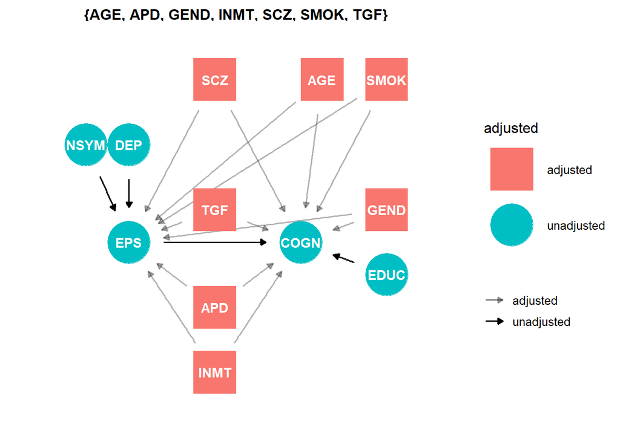

```r
coords <- list(
  x = c(EPS  = 0,
        COGN = 8,
        APD = 4,
        TGF = 4,
        SCZ = 4,
        EDUC = 12,
        GEND = 12,
        AGE = 9,
        SMOK = 12,
        CTYP = 12,
        AMAN = 12,
        DEP = 0,
        NSYM = -2,
        INMT = 4),
  y = c(EPS  = 1,
        COGN = 1,
        APD = -1,
        TGF = 2,
        SCZ = 6,
        EDUC = 0,
        GEND = 2,
        AGE = 6,
        AGE = 4,
        SMOK = 6,
        CTYP = 4,
        AMAN = 5,
        DEP = 4,
        NSYM = 4,
        INMT = -3)
)

# Создание DAG
dag <- ggdag::dagify(
  EPS  ~ APD + TGF + SCZ + DEP + NSYM + INMT,
  COGN ~ EPS  + EPS  + APD + TGF + SCZ + EDUC + GEND + AGE + SMOK + INMT,
  EPS  ~ DEP + APD + TGF + SCZ + GEND + AGE + SMOK,
  exposure = "EPS",
  outcome = "COGN",
  coords = coords
)

# Визуализация DAG с ggplot2
ggdag_adjustment_set(dag, shadow = T) +
    theme_dag()
```

# 3. Dynamics

Creating a dataframe containing the difference in quantitative indicators between visits. Using make_difference_df.R

```r
path <- here("scripts/0_preprocessing", "make_difference_df.R")
source(path)
difference_df <- make_dif_df(data_filtered)
```

## 3.1 Difference between visits

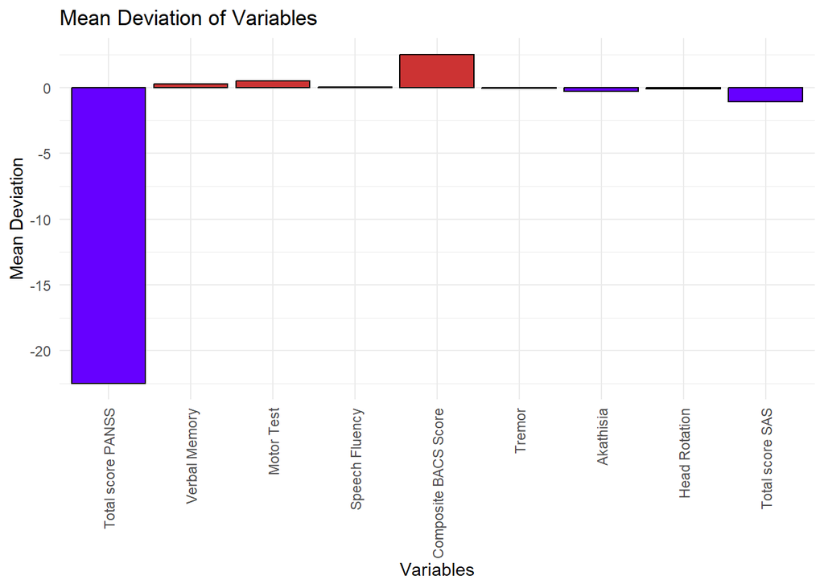

```r
difference_df %>%
  gather(variable, value, -id) %>%
  filter(!grepl("G[1-9]|N[1-7]|P[1-7]_dif$", variable)) %>%
  group_by(variable) %>%
  summarise(mean_value = mean(value, na.rm = TRUE)) %>%
  filter(grepl("_dif$", variable)) %>%
  mutate(variable = gsub("_dif$", "", variable)) %>%
  filter(variable %in% c("Total score PANSS", "tremor", "akathisia", "head rotation", "Total score SAS", "ZVM", "ZTol", "ZMT", "ZVF", "Comp Z")) %>%
  mutate(variable = case_when(
    variable == "ZVM" ~ "Verbal Memory",
    variable == "ZMT" ~ "Motor Test",
    variable == "ZVF" ~ "Speech Fluency",
    variable == "ZTol" ~ "Tower of London",
    variable == "Comp Z" ~ "Composite BACS Score",
    variable == "tremor" ~ "Tremor",
    variable == "akathisia" ~ "Akathisia",
    variable == "head rotation" ~ "Head Rotation",
    variable == "Total score SAS" ~ "Total score SAS",
    TRUE ~ variable
  )) %>%
  mutate(variable = factor(variable, levels = c("Total score PANSS", "Verbal Memory", "Motor Test", "Speech Fluency", "Tower of London", "Composite BACS Score", "Tremor", "Akathisia", "Head Rotation", "Total score SAS"))) %>%
  ggplot(aes(x = variable, y = mean_value, fill = factor(sign(mean_value)))) +
  geom_bar(stat = "identity", color = "black") +
  scale_fill_manual(values = c("#6600FF", "#CC3333", "green"), name = "Sign", labels = c("Negative", "Zero", "Positive")) +
  labs(title = "Mean Deviation of Variables",
       x = "Variables",
       y = "Mean Deviation") +
  theme_minimal() +
  guides(fill = FALSE) +
  theme(axis.text.x = element_text(angle = 90, vjust = 0.5, hjust = 1))
```

## 3.2 Correlation analysis

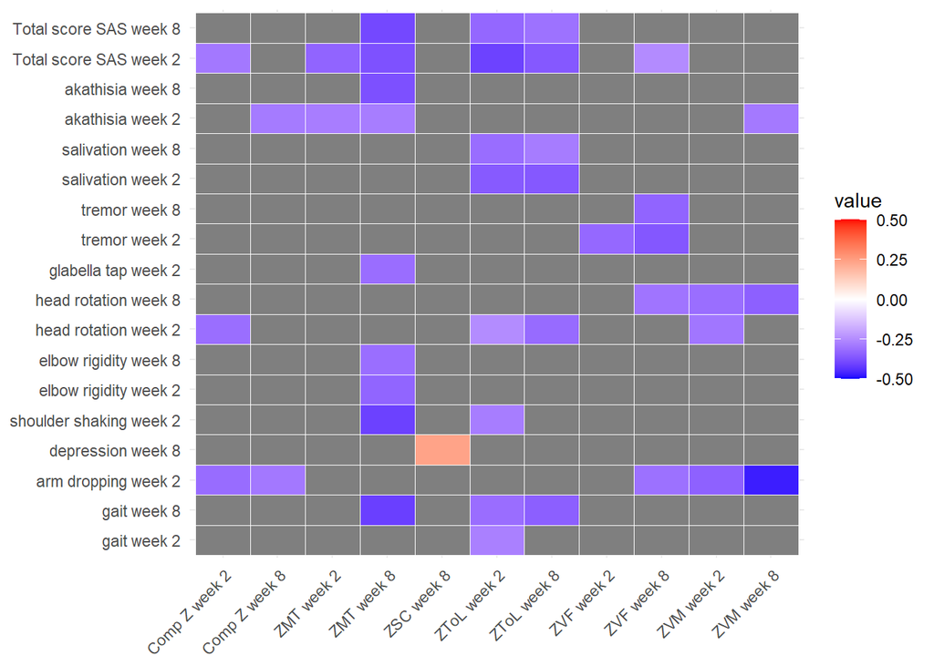

```r
text_data <- "
,gait_week_2,gait_week_8,arm_dropping_week_2,depression_week_8,shoulder_shaking_week_2,elbow_rigidity_week_2,elbow_rigidity_week_8,head_rotation_week_2,head_rotation_week_8,glabella_tap_week_2,tremor_week_2,tremor_week_8,salivation_week_2,salivation_week_8,akathisia_week_2,akathisia_week_8,Total_score_SAS_week_2,Total_score_SAS_week_8
ZVM_week_2,,,-0.342,,,,,-0.297,-0.314,,,,,,,,,
ZVM_week_8,,,-0.471,,,,,,-0.344,,,,,,-0.29,,,
ZMT_week_2,,,,,,,,,,,,,,,-0.28,,-0.335,
ZMT_week_8,,-0.412,,,-0.409,-0.334,-0.313,,,-0.315,,,,,-0.281,-0.378,-0.376,-0.395
ZVF_week_2,,,,,,,,,,,-0.326,,,,,,,
ZVF_week_8,,,-0.308,,,,,,-0.3,,-0.364,-0.335,,,,,-0.25,
ZSC_week_8,,,,0.237,,,,,,,,,,,,,,
ZToL_week_2,-0.274,-0.315,,,-0.281,,,-0.249,,,,,-0.357,-0.317,,,-0.407,-0.329
ZToL_week_8,,-0.347,,,,,,-0.321,,,,,-0.361,-0.283,,,-0.362,-0.306
Comp_Z_week_2,,,-0.318,,,,,-0.314,,,,,,,,,-0.293,
Comp_Z_week_8,,,-0.291,,,,,,,,,,,,-0.286,,,
"

# Create a data frame with row names
your_data <- as.data.frame(read.table(text = text_data, sep = ",", row.names = 1, header = TRUE, quote = ""))

# Extract row names and column names
row_names <- rownames(your_data)
col_names <- colnames(your_data)


# Replace underscores with spaces
row_names <- gsub("_", " ", row_names)
col_names <- gsub("_", " ", col_names)


# Convert to a data frame
df <- your_data
df$row_names <- row_names

# Load library with suppressed messages
suppressMessages(library(plotly))

# Melt the data for ggplot
melted_df <- reshape2::melt(df, id.vars = "row_names", variable.name = "col_names")

# Create the heatmap using ggplot2
ggplot(melted_df, aes(x = col_names, y = row_names, fill = value)) +
  geom_tile(color = "white") +
  scale_fill_gradient2(low = "blue", high = "red", mid = "white", midpoint = 0, limit = c(-0.5, 0.5)) +
  theme_minimal() +
  theme(legend.position = "right", axis.text.x = element_text(angle = 45, hjust = 1, vjust = 1), axis.title = element_blank())+
  scale_x_discrete(labels = col_names)+coord_flip()
```

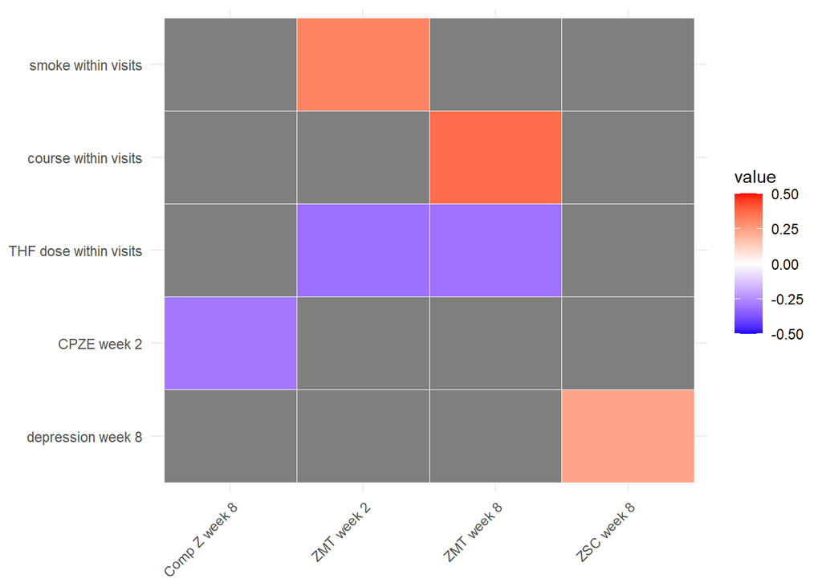

```r
text_data <- "
,depression_week_8,CPZE_week_2,THF_dose_within_visits,course_within_visits,smoke_within_visits
ZMT_week_2,,,-0.311,,0.315
ZMT_week_8,,,-0.305,0.363,
ZSC_week_8,0.237,,,,
Comp_Z_week_8,,-0.293,,,
"

# Create a data frame with row names
your_data <- as.data.frame(read.table(text = text_data, sep = ",", row.names = 1, header = TRUE, quote = ""))

# Extract row names and column names
row_names <- rownames(your_data)
col_names <- colnames(your_data)


# Replace underscores with spaces
row_names <- gsub("_", " ", row_names)
col_names <- gsub("_", " ", col_names)


# Convert to a data frame
df <- your_data
df$row_names <- row_names


# Melt the data for ggplot
melted_df <- reshape2::melt(df, id.vars = "row_names", variable.name = "col_names")

# Create the heatmap using ggplot2
ggplot(melted_df, aes(x = col_names, y = row_names, fill = value)) +
  geom_tile(color = "white") +
  scale_fill_gradient2(low = "blue", high = "red", mid = "white", midpoint = 0, limit = c(-0.5, 0.5)) +
  theme_minimal() +
  theme(legend.position = "right", axis.text.x = element_text(angle = 45, hjust = 1, vjust = 1), axis.title = element_blank())+
  scale_x_discrete(labels = col_names)+coord_flip()
```

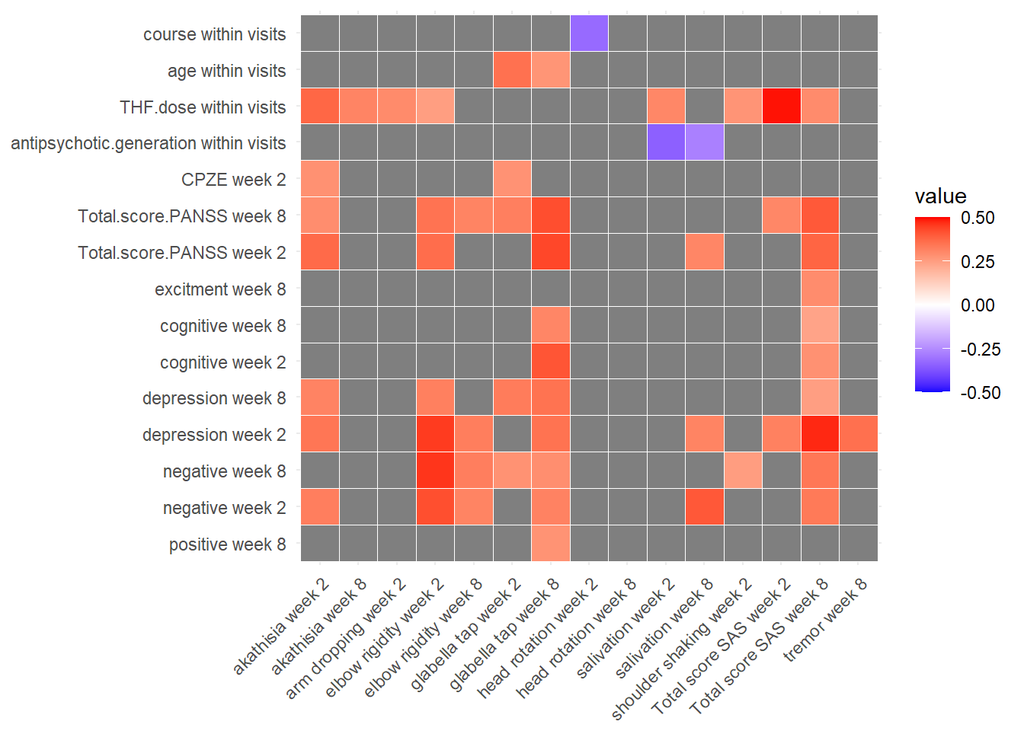

```r
text_data <- "
,positive_week_8,negative_week_2,negative_week_8,depression_week_2,depression_week_8,cognitive_week_2,cognitive_week_8,excitment_week_8,Total.score.PANSS_week_2,Total.score.PANSS_week_8,CPZE_week_2,antipsychotic.generation_within_visits,THF.dose_within_visits,age_within_visits,course_within_visits
arm_dropping_week_2,,,,,,,,,,,,,0.296,,
shoulder_shaking_week_2,,,0.253,,,,,,,,,,0.274,,
elbow_rigidity_week_2,,0.423,0.462,0.454,0.322,,,,0.363,0.35,,,0.251,,
elbow_rigidity_week_8,,0.313,0.325,0.326,,,,,,0.313,,,,,
head_rotation_week_2,,,,,,,,,,,,,,,-0.322
head_rotation_week_8,,,,,,,,,,,,,,,
glabella_tap_week_2,,,0.28,,0.33,,,,,0.323,0.278,,,0.354,
glabella_tap_week_8,0.277,0.316,0.288,0.351,0.351,0.411,0.308,,0.436,0.424,,,,0.273,
tremor_week_8,,,,0.357,,,,,,,,,,,
salivation_week_2,,,,,,,,,,,,-0.344,0.305,,
salivation_week_8,,0.405,,0.313,,,,,0.307,,,-0.275,,,
akathisia_week_2,,0.325,,0.343,0.314,,,,0.37,0.29,0.282,,0.377,,
akathisia_week_8,,,,,,,,,,,,,0.312,,
Total_score_SAS_week_2,,,,0.319,,,,,,0.305,,,0.493,,
Total_score_SAS_week_8,,0.336,0.341,0.476,0.249,0.282,0.237,0.293,0.381,0.403,,,0.295,,
"

# Create a data frame with row names
your_data <- as.data.frame(read.table(text = text_data, sep = ",", row.names = 1, header = TRUE, quote = ""))

# Extract row names and column names
row_names <- rownames(your_data)
col_names <- colnames(your_data)


# Replace underscores with spaces
row_names <- gsub("_", " ", row_names)
col_names <- gsub("_", " ", col_names)


# Convert to a data frame
df <- your_data
df$row_names <- row_names


# Melt the data for ggplot
melted_df <- reshape2::melt(df, id.vars = "row_names", variable.name = "col_names")

# Create the heatmap using ggplot2
ggplot(melted_df, aes(x = col_names, y = row_names, fill = value)) +
  geom_tile(color = "white") +
  scale_fill_gradient2(low = "blue", high = "red", mid = "white", midpoint = 0, limit = c(-0.5, 0.5)) +
  theme_minimal() +
  theme(legend.position = "right", axis.text.x = element_text(angle = 45, hjust = 1, vjust = 1), axis.title = element_blank())+
  scale_x_discrete(labels = col_names)+coord_flip()
```

# 4. Building models

## 4.1 Cognitive assessment models

1.1.1 ZVM ~ `Total score PANSS` + `THF dose`

1.1.2 ZVM ~ `head rotation` + `Total score PANSS` + `THF dose`

1.2.1 ZMT ~ `Total score PANSS` + `THF dose`

1.2.2 ZMT ~ akathisia + `Total score PANSS` + `THF dose`

1.3. ZMT ~ `Total score SAS` + `Total score PANSS` + `THF dose`

1.5 ZToL ~ `Total score SAS` + `Total score PANSS` + `THF dose`

```r
model_1_1_1 <- lm(ZVM ~ `Total score PANSS` + `THF dose`, data = data_filtered)
model_1_1_2 <- lm(ZVM ~ `head rotation` + `Total score PANSS` + `THF dose`, data = data_filtered)

model_1_2_1 <- lm(ZMT ~ `Total score PANSS` + `THF dose`, data = data_filtered)
model_1_2_2 <- lm(ZMT ~ akathisia + `Total score PANSS` + `THF dose`, data = data_filtered)

model_1_3 <- lm(ZMT ~ `Total score SAS` + `Total score PANSS` + `THF dose`, data = data_filtered)

model_1_4_1 <- lm(ZVF ~ `Total score PANSS` + `THF dose`, data = data_filtered)

model_1_4_2 <- lm(ZVF ~ tremor + `Total score PANSS` + `THF dose`, data = data_filtered)

model_1_5 <- lm(ZToL ~ `Total score SAS` + `Total score PANSS` + `THF dose`, data = data_filtered)
```

We compare pairwise and take p-value

- model_1_1_1 and model_1_1_2
- model_1_2_1 and model_1_2_2
- model_1_4_1 and model_1_4_2

For models model_1_3 and model_1_5 we take p-value for `Total score SAS` Benjamin Hochberg’s correction was used.

```r
# Comparing models using anova
anova_result_1 <- anova(model_1_1_1, model_1_1_2)
anova_result_2 <- anova(model_1_2_1, model_1_2_2)
summary_3 <- model_1_3 %>% summary()
anova_result_4 <- anova(model_1_4_1, model_1_4_2)
summary_5 <- model_1_5 %>% summary()

# Extracting p-values from the second element of the array Pr(>F) for each comparison
p_value_1 <- anova_result_1$`Pr(>F)`[2]
p_value_2 <- anova_result_2$`Pr(>F)`[2]
p_value_3 <- summary_3$coefficients[14]
p_value_4 <- anova_result_4$`Pr(>F)`[2]
p_value_5 <- summary_5$coefficients[14]

# Creating a tibble with p-values
tibble(
  Model = c("ZVM", "ZMT_1", "ZMT_2", "ZVF", "ZToL"),
  P_Value = round(c(p_value_1, p_value_2, p_value_3, p_value_4, p_value_5), 3),
  P_Adjusted = round(p.adjust(c(p_value_1, p_value_2, p_value_3, p_value_4, p_value_5), method = "BH"), 3)
) %>%  kable(format = "html") %>%
  kable_styling("striped", full_width = FALSE)
```

| Model | P_Value | P_Adjusted |
| --- | --- | --- |
| ZVM | 0.003 | 0.005 |
| ZMT_1 | 0.330 | 0.330 |
| ZMT_2 | 0.189 | 0.236 |
| ZVF | 0.003 | 0.005 |
| ZToL | 0.000 | 0.001 |

```r
# Creating a function to obtain summary and convert it to a table
get_lm_summary_table <- function(model, dependent_variable) {
  summary_data <- summary(model)

  # Extracting the desired data from summary
  coefficients <- summary_data$coefficients[, c("Estimate", "Std. Error", "t value", "Pr(>|t|)")]

  # Creating a table
  table_data <- as.data.frame(coefficients)
  table_data$Variable <- rownames(coefficients)
  rownames(table_data) <- NULL

  # Rounding to 3 decimal places
  table_data$Estimate <- round(table_data$Estimate, 3)
  table_data$`Std. Error` <- round(table_data$`Std. Error`, 3)
  table_data$`t value` <- round(table_data$`t value`, 3)
  table_data$`Pr(>|t|)` <- round(table_data$`Pr(>|t|)`, 3)

  # Adding the name of the dependent variable
  table_data <- cbind(Dependent_Variable = dependent_variable, table_data)

  return(table_data)
}

# Obtaining tables for each model
table_ZVM_1 <- get_lm_summary_table(model_1_1_1, "ZVM_1")
table_ZVM_2 <- get_lm_summary_table(model_1_1_2, "ZVM_2")

table_ZMT_1_1 <- get_lm_summary_table(model_1_2_1, "ZMT_1_1")
table_ZMT_1_2 <- get_lm_summary_table(model_1_2_2, "ZMT_1_2")

table_ZMT_2 <- get_lm_summary_table(model_1_3, "ZMT_2")

table_ZVF_1 <- get_lm_summary_table(model_1_4_1, "ZVF_1")
table_ZVF_2 <- get_lm_summary_table(model_1_4_2, "ZVF_2")

table_ZToL <- get_lm_summary_table(model_1_5, "ZToL")

# Combining tables into one
final_table <- rbind(table_ZVM_1, table_ZVM_2, table_ZMT_1_1, table_ZMT_1_2, table_ZMT_2, table_ZVF_1, table_ZVF_2, table_ZToL)

# Displaying the table
kable(final_table, format = "html") %>%
  kable_styling("striped", full_width = FALSE)
```

| Dependent_Variable | Estimate | Std. Error | t value | Pr(>\|t\|) | Variable |
| --- | --- | --- | --- | --- | --- |
| ZVM_1 | -1.185 | 0.598 | -1.981 | 0.050 | (Intercept) |
| ZVM_1 | -0.004 | 0.008 | -0.468 | 0.641 | `Total score PANSS` |
| ZVM_1 | -0.039 | 0.052 | -0.747 | 0.457 | `THF dose` |
| ZVM_2 | -1.071 | 0.578 | -1.853 | 0.067 | (Intercept) |
| ZVM_2 | -0.578 | 0.191 | -3.025 | 0.003 | `head rotation` |
| ZVM_2 | -0.004 | 0.008 | -0.532 | 0.596 | `Total score PANSS` |
| ZVM_2 | -0.003 | 0.051 | -0.050 | 0.960 | `THF dose` |
| ZMT_1_1 | 1.275 | 0.591 | 2.158 | 0.033 | (Intercept) |
| ZMT_1_1 | -0.013 | 0.008 | -1.712 | 0.090 | `Total score PANSS` |
| ZMT_1_1 | -0.204 | 0.051 | -3.997 | 0.000 | `THF dose` |
| ZMT_1_2 | 1.068 | 0.627 | 1.703 | 0.092 | (Intercept) |
| ZMT_1_2 | -0.204 | 0.208 | -0.979 | 0.330 | akathisia |
| ZMT_1_2 | -0.011 | 0.008 | -1.246 | 0.216 | `Total score PANSS` |
| ZMT_1_2 | -0.184 | 0.055 | -3.379 | 0.001 | `THF dose` |
| ZMT_2 | 1.221 | 0.590 | 2.069 | 0.041 | (Intercept) |
| ZMT_2 | -0.057 | 0.043 | -1.322 | 0.189 | `Total score SAS` |
| ZMT_2 | -0.010 | 0.008 | -1.157 | 0.250 | `Total score PANSS` |
| ZMT_2 | -0.174 | 0.055 | -3.151 | 0.002 | `THF dose` |
| ZVF_1 | -0.799 | 0.464 | -1.722 | 0.088 | (Intercept) |
| ZVF_1 | 0.001 | 0.006 | 0.240 | 0.811 | `Total score PANSS` |
| ZVF_1 | -0.119 | 0.040 | -2.973 | 0.004 | `THF dose` |
| ZVF_2 | -0.686 | 0.448 | -1.532 | 0.129 | (Intercept) |
| ZVF_2 | -0.410 | 0.133 | -3.087 | 0.003 | tremor |
| ZVF_2 | 0.004 | 0.006 | 0.613 | 0.541 | `Total score PANSS` |
| ZVF_2 | -0.093 | 0.039 | -2.353 | 0.020 | `THF dose` |
| ZToL | 0.815 | 0.710 | 1.148 | 0.254 | (Intercept) |
| ZToL | -0.209 | 0.052 | -4.015 | 0.000 | `Total score SAS` |
| ZToL | -0.006 | 0.010 | -0.635 | 0.527 | `Total score PANSS` |
| ZToL | 0.029 | 0.067 | 0.441 | 0.660 | `THF dose` |

Divide by visits

```r
model_ZVM_visit_1 <- lm(ZVM ~ `head rotation` + `Total score PANSS` + `THF dose`, data = data_filtered %>% filter(visit==1))
model_ZVM_visit_2 <- lm(ZVM ~ `head rotation` + `Total score PANSS` + `THF dose`, data = data_filtered %>% filter(visit==2))

model_ZMT_1_visit_1 <- lm(ZMT ~ akathisia + `Total score PANSS` + `THF dose`, data = data_filtered %>% filter(visit==1))
model_ZMT_1_visit_2 <- lm(ZMT ~ akathisia + `Total score PANSS` + `THF dose`, data = data_filtered %>% filter(visit==2))

model_ZMT_2_visit_1 <- lm(ZMT ~ `Total score SAS` + `Total score PANSS` + `THF dose`, data = data_filtered %>% filter(visit==1))
model_ZMT_2_visit_2 <- lm(ZMT ~ `Total score SAS` + `Total score PANSS` + `THF dose`, data = data_filtered %>% filter(visit==2))

model_ZVF_visit_1 <- lm(ZVF ~ tremor + `Total score PANSS` + `THF dose`, data = data_filtered %>% filter(visit==1))
model_ZVF_visit_2 <- lm(ZVF ~ tremor + `Total score PANSS` + `THF dose`, data = data_filtered %>% filter(visit==2))

model_ZToL_visit_1 <- lm(ZToL ~ `Total score SAS` + `Total score PANSS` + `THF dose`, data = data_filtered %>% filter(visit==1))
model_ZToL_visit_2 <- lm(ZToL ~ `Total score SAS` + `Total score PANSS` + `THF dose`, data = data_filtered %>% filter(visit==1))

# Creating a function to obtain summary and convert it to a table
get_lm_summary_table <- function(model, dependent_variable) {
  summary_data <- summary(model)

  # Extracting the desired data from summary
  coefficients <- summary_data$coefficients[, c("Estimate", "Std. Error", "t value", "Pr(>|t|)")]

  # Creating a table
  table_data <- as.data.frame(coefficients)
  table_data$Variable <- rownames(coefficients)
  rownames(table_data) <- NULL

  # Rounding to 3 decimal places
  table_data$Estimate <- round(table_data$Estimate, 3)
  table_data$`Std. Error` <- round(table_data$`Std. Error`, 3)
  table_data$`t value` <- round(table_data$`t value`, 3)
  table_data$`Pr(>|t|)` <- round(table_data$`Pr(>|t|)`, 3)

  # Adding the name of the dependent variable
  table_data <- cbind(Dependent_Variable = dependent_variable, table_data)

  return(table_data)
}

# Obtaining tables for each model
table_ZVM_visit_1 <- get_lm_summary_table(model_ZVM_visit_1, "ZVM_visit_1")
table_ZVM_visit_2 <- get_lm_summary_table(model_ZVM_visit_2, "ZVM_visit_2")

table_ZMT_1_visit_1 <- get_lm_summary_table(model_ZMT_1_visit_1, "ZMT_1_visit_1")
table_ZMT_1_visit_2 <- get_lm_summary_table(model_ZMT_1_visit_2, "ZMT_1_visit_2")

table_ZMT_2_visit_1 <- get_lm_summary_table(model_ZMT_2_visit_1, "ZMT_2_visit_1")
table_ZMT_2_visit_2 <- get_lm_summary_table(model_ZMT_2_visit_2, "ZMT_2_visit_2")

table_ZVF_visit_1 <- get_lm_summary_table(model_ZVF_visit_1, "ZVF_visit_1")
table_ZVF_visit_2 <- get_lm_summary_table(model_ZVF_visit_2, "ZVF_visit_2")

table_ZToL_visit_1 <- get_lm_summary_table(model_ZToL_visit_1, "ZToL_visit_1")
table_ZToL_visit_2 <- get_lm_summary_table(model_ZToL_visit_2, "ZToL_visit_2")

# Combining tables into one
final_table <- rbind(table_ZVM_visit_1, table_ZVM_visit_2, table_ZMT_1_visit_1, table_ZMT_1_visit_2,
                     table_ZMT_2_visit_1, table_ZMT_2_visit_2, table_ZVF_visit_1, table_ZVF_visit_2,
                     table_ZToL_visit_1, table_ZToL_visit_2)

# Displaying the table
kable(final_table, format = "html") %>%
  kable_styling("striped", full_width = FALSE)
```

[output not shown]

## 4.2 EPS models logistic regression

```r
data_for_logr <- data_filtered %>%
  mutate(
    head_rotation_bin = ifelse(`head rotation` < 2, 0, 1),
    tremor_bin = ifelse(tremor < 2, 0, 1),
    akathisia_bin = ifelse(akathisia < 2, 0, 1),
    )

model_head <- glm(head_rotation_bin ~ CPZE + `Total score PANSS`, family = binomial, data = data_for_logr)
summary_head <- tidy(model_head)
model_tremor <- glm(tremor_bin ~ CPZE + `Total score PANSS`, family = binomial, data = data_for_logr)
summary_tremor <- tidy(model_tremor)
model_akathisia <- glm(akathisia_bin ~ CPZE + `Total score PANSS`, family = binomial, data = data_for_logr)
summary_akathisia <- tidy(model_akathisia)
model_total_score <- lm(`Total score SAS` ~ CPZE + `Total score PANSS`, data = data_filtered)
summary_total_score <- tidy(model_total_score)

# Rounding coefficients to 3 decimal places
round_summary <- function(summary) {
  summary$estimate <- round(summary$estimate, 3)
  summary$std.error <- round(summary$std.error, 3)
  summary$statistic <- round(summary$statistic, 3)
  summary$p.value <- round(summary$p.value, 3)
  return(summary)
}

# Combining and rounding the results into one table
result_table <- bind_rows(
  mutate(round_summary(summary_head), Outcome = "Head Rotation"),
  mutate(round_summary(summary_tremor), Outcome = "Tremor"),
  mutate(round_summary(summary_akathisia), Outcome = "Akathisia"),
  mutate(round_summary(summary_total_score), Outcome = "Total Score SAS")
)

# Displaying the table
kable(result_table, format = "html") %>%
  kable_styling("striped", full_width = FALSE)
```

| term | estimate | std.error | statistic | p.value | Outcome |
| --- | --- | --- | --- | --- | --- |
| (Intercept) | -2.350 | 1.456 | -1.614 | 0.107 | Head Rotation |
| CPZE | 0.047 | 0.111 | 0.424 | 0.672 | Head Rotation |
| `Total score PANSS` | -0.002 | 0.020 | -0.084 | 0.933 | Head Rotation |
| (Intercept) | -2.380 | 1.064 | -2.236 | 0.025 | Tremor |
| CPZE | -0.004 | 0.088 | -0.043 | 0.965 | Tremor |
| `Total score PANSS` | 0.014 | 0.014 | 0.980 | 0.327 | Tremor |
| (Intercept) | -6.730 | 1.694 | -3.973 | 0.000 | Akathisia |
| CPZE | 0.133 | 0.113 | 1.180 | 0.238 | Akathisia |
| `Total score PANSS` | 0.049 | 0.019 | 2.566 | 0.010 | Akathisia |
| (Intercept) | 0.208 | 1.433 | 0.145 | 0.885 | Total Score SAS |
| CPZE | 0.144 | 0.118 | 1.224 | 0.224 | Total Score SAS |
| `Total score PANSS` | 0.068 | 0.019 | 3.516 | 0.001 | Total Score SAS |